# Advanced Modelling Final Project

Anita Di Gennaro

2026-03-12

## The Data

For this research, a very comprehensive data set regarding the economic impact of wars was selected. It has 28 variables, comprising both categorical and continuous variables, and it encompasses both resolved and ongoing conflicts. For each conflict, the data set provides an array of information regarding different sectors and how the war impacted them. With the ‘primary_country’ variable, the data frame specifies to which of the countries involved in the conflict the information refers to.

To conduct my research exploring the economic impacts of wars, the conflicts selected are the ongoing ones. This was done to gather a more contemporary and socially relevant investigation on the observed consequences of the current conflicts so far.

```r
data <- read.csv("war_economic_impact_dataset.csv")

data_filtered <- data |>
  filter(Status == "Ongoing")

data_filtered <- data_filtered |>
  dplyr::select(-c(Status, Conflict_Type, End_Year))
```

Given the focus on ongoing conflicts, the ‘status’ variable, as well as the ‘end_year’ variable were removed. I also removed the ‘conflict_type’ as I did not deem it a relevant information for this inquiry.

RESEARCH QUESTIONS: This inquiry will investigate the economic effects of the ongoing conflicts, and how the involved countries are being affected. The humanitarian, economic and societal impacts of war need to be studied as a way to understand and shed light on the effects of war as a whole.

Regarding the target variables that will be at the center of this project, the regression models will be performed with ‘Food_Insecurity_Rate’ as the dependent variable, while the classification models will use ‘War_Profiteering_Documented’, a binary variable. Hopefully, the analysis done through both classification and regression methods will provide a rounded understanding of the changes in food security and in war profiteering factors during war times, in ongoing conflicts.

Food insecurity captures the humanitarian dimension of conflict, highlighting the swift changes that happen during war times and how the populations’ conditions can worsen in a very short amount of time, often leading to humanitarian crises. War profiteering focuses on a more economical scope of war, but still important to understand its effects on a societal scale.

## Data Cleaning and Exploration

```r
summary(data_filtered)
```

```
##  Conflict_Name         Region            Start_Year   Primary_Country
##  Length:54478       Length:54478       Min.   :1996   Length:54478
##  Class :character   Class :character   1st Qu.:2011   Class :character
##  Mode  :character   Mode  :character   Median :2022   Mode  :character
##                                        Mean   :2015
##                                        3rd Qu.:2023
##                                        Max.   :2025
##  Pre_War_Unemployment_. During_War_Unemployment_.
##  Min.   : 3.000         Min.   : 3.37
##  1st Qu.: 6.040         1st Qu.:14.30
##  Median : 9.040         Median :22.09
##  Mean   : 9.025         Mean   :26.11
##  3rd Qu.:12.010         3rd Qu.:33.60
##  Max.   :15.000         Max.   :89.40
##  Unemployment_Spike_Percentage_Points Most_Affected_Sector
##  Min.   : 0.33                        Length:54478
##  1st Qu.: 6.60                        Class :character
##  Median :12.89                        Mode  :character
##  Mean   :17.08
##  3rd Qu.:22.99
##  Max.   :74.47
##  Youth_Unemployment_Change_. Pre_War_Poverty_Rate_. During_War_Poverty_Rate_.
##  Min.   :  0.40              Min.   : 5.00          Min.   : 5.40
##  1st Qu.:  8.52              1st Qu.:11.30          1st Qu.:21.67
##  Median : 16.73              Median :17.53          Median :29.86
##  Mean   : 22.21              Mean   :17.53          Mean   :32.04
##  3rd Qu.: 29.86              3rd Qu.:23.79          3rd Qu.:39.20
##  Max.   :108.71              Max.   :30.00          Max.   :98.00
##  Extreme_Poverty_Rate_. Food_Insecurity_Rate_.
##  Min.   : 1.84          Min.   : 3.19
##  1st Qu.:10.00          1st Qu.:14.59
##  Median :14.37          Median :20.42
##  Mean   :16.03          Mean   :22.41
##  3rd Qu.:20.14          3rd Qu.:27.86
##  Max.   :68.49          Max.   :86.32
##  Households_Fallen_Into_Poverty_Estimate  GDP_Change_.    Inflation_Rate_.
##  Min.   :       6                        Min.   :-85.00   Min.   :  0.17
##  1st Qu.:    5782                        1st Qu.:-45.58   1st Qu.: 42.68
##  Median :   22174                        Median :-31.87   Median : 69.31
##  Mean   :  158976                        Mean   :-35.02   Mean   : 70.02
```

[output cut: 15 more lines]

```
##  Max.   :40.00                   Max.   :90.00
##  Black_Market_Activity_Level Primary_Black_Market_Goods
##  Length:54478                Length:54478
##  Class :character            Class :character
##  Mode  :character            Mode  :character
##
##
##
##  Currency_Black_Market_Rate_Gap_. War_Profiteering_Documented
##  Min.   :  0.00                   Length:54478
##  1st Qu.:  9.35                   Class :character
##  Median : 18.73                   Mode  :character
##  Mean   :126.25
##  3rd Qu.:241.32
##  Max.   :500.00
```

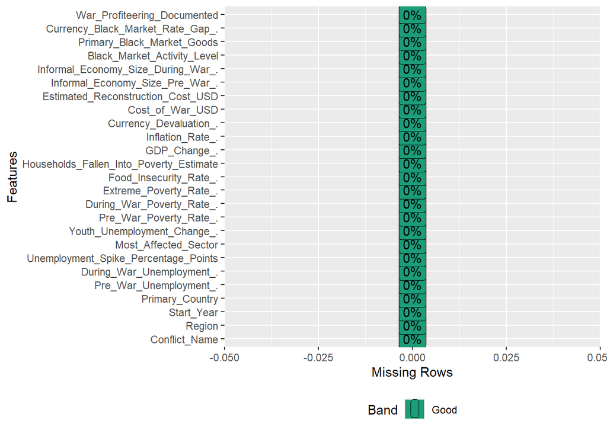

```r
plot_missing(data_filtered)
```

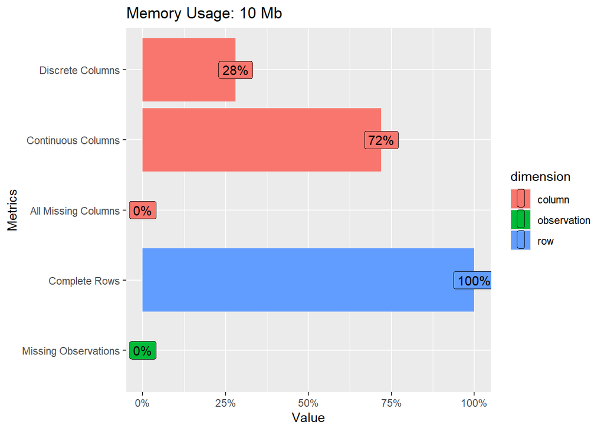

```r
plot_intro(data_filtered)
```

The data set presents no missing data. The majority of the columns are continuous.

From an initial summary it can be noticed that most ongoing conflicts have started after 2011, with the most recent conflict starting in 2025, between Iran and Israel, the 15-days war that here is marked as still ongoing given the most recent developments. The oldest war here started 1996, the Second Congo civil war.

As predictable, unemployment rates increase with the conflicts’ development. This can be also seen by looking at the percentage points of unemployment spikes and youth unemployment rates. The data set also provides poverty rates, both before and during the wars, as well as the food insecurity rates and the households that fell into poverty since the conflict’s development. The GDP change has all negative values, further showcasing the increase of poverty. The data set provides information regarding the changes within the black market as the wars started, among which the primary types of goods being sold and the market’s activity levels.

### - exploratory graphs

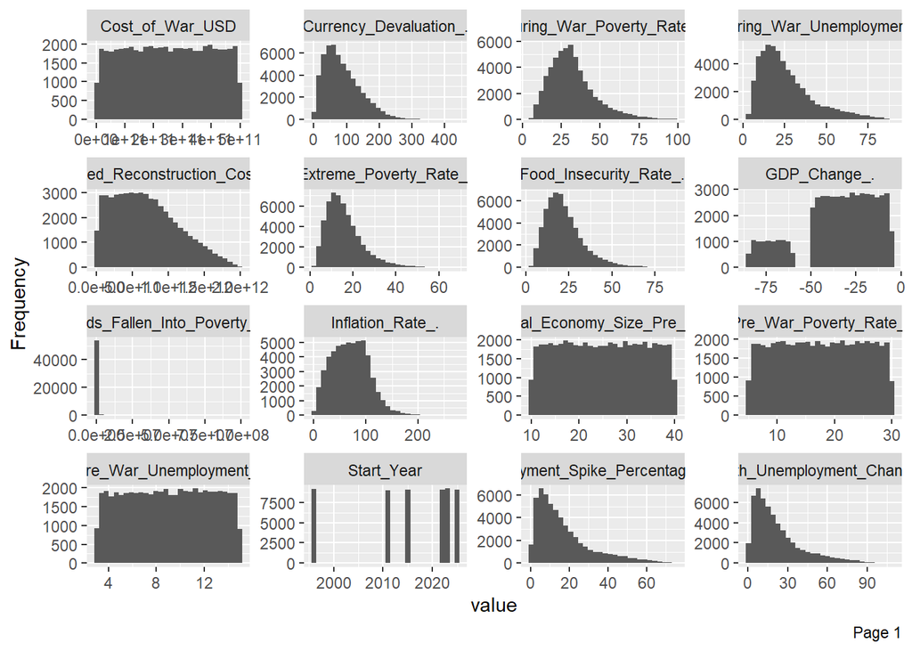

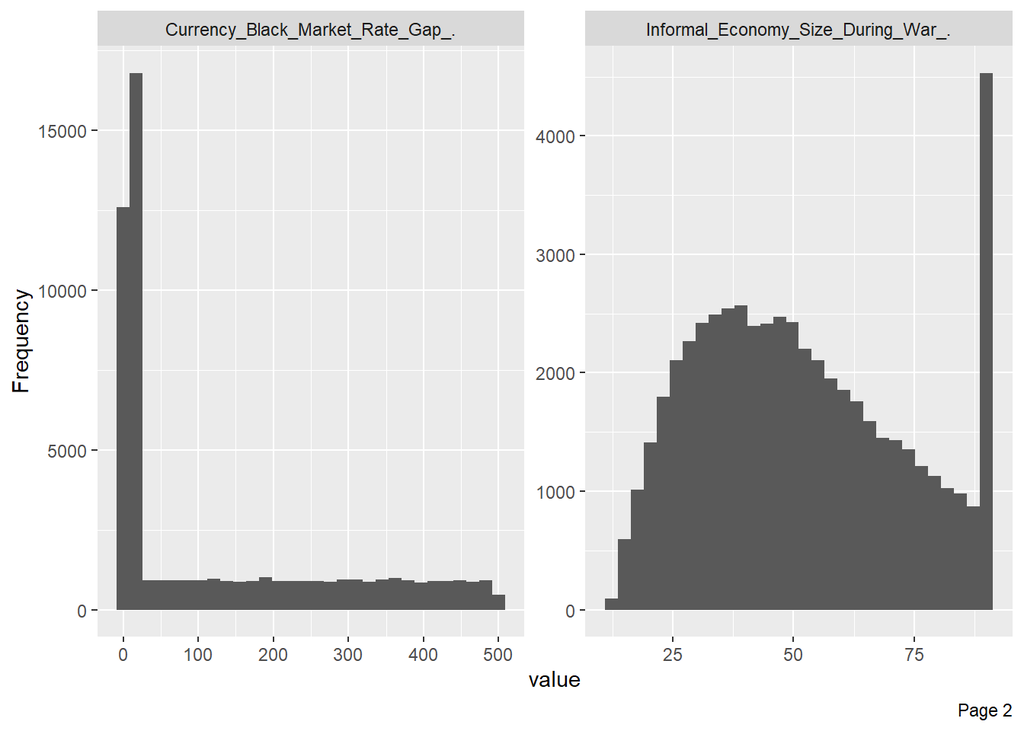

```r
plot_histogram(data_filtered)
```

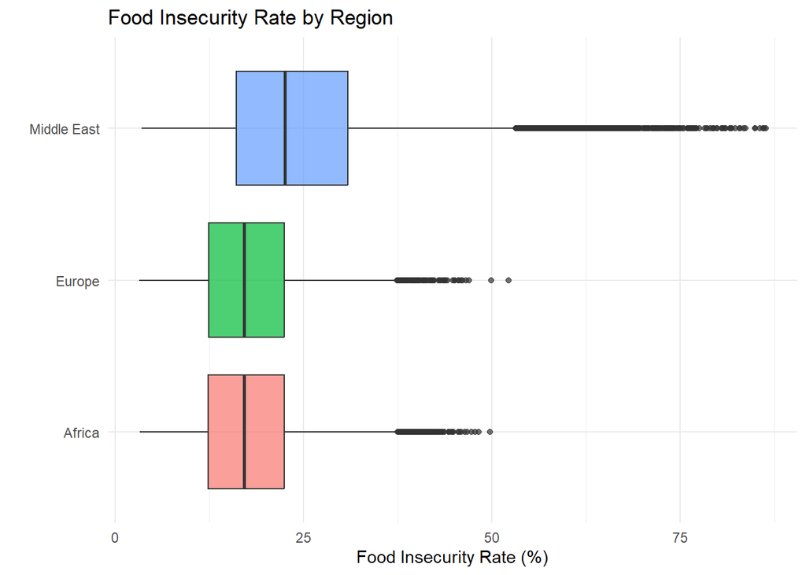

```r
#food insecurity rate by region
data_filtered |>
  ggplot(aes(x = reorder(Region, Food_Insecurity_Rate_., median),
             y = Food_Insecurity_Rate_., fill = Region)) +
  geom_boxplot(alpha = 0.7, show.legend = FALSE) +
  coord_flip() +
  labs(
    title = "Food Insecurity Rate by Region",
    x = "", y = "Food Insecurity Rate (%)"
  ) +
  theme_minimal()
```

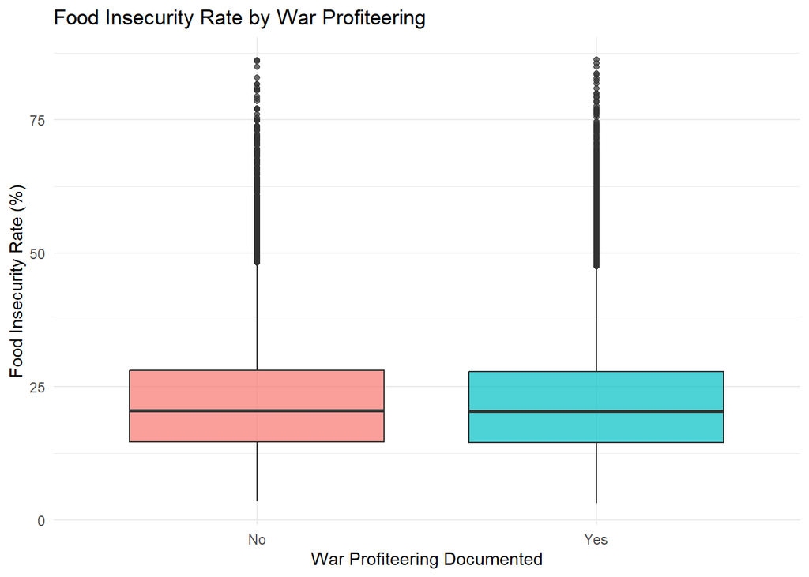

```r
#food insecurity rate by war profiteering documented
data_filtered |>
  ggplot(aes(x = War_Profiteering_Documented,
             y = Food_Insecurity_Rate_.,
             fill = War_Profiteering_Documented)) +
  geom_boxplot(alpha = 0.7, show.legend = FALSE) +
  labs(
    title = "Food Insecurity Rate by War Profiteering",
    x = "War Profiteering Documented", y = "Food Insecurity Rate (%)"
  ) +
  theme_minimal()
```

The main takeaways from an initial analysis distribution is the possible need of some transformation of the data to make it more normally distributed.

When looking at the box plot of food insecurity across regions, it ca be noted that the Middle East stands out with a longer tail and quite a lot of extreme, reflecting the severe humanitarian crises associated with conflicts such as the Israel-Palestine war and the Syrian civil war. Africa and Europe show more contained distributions with lower median food insecurity rates, though both present notable outliers. While extreme food insecurity is less common in these regions, individual conflicts can still drive severe outcomes. The second box plot does not show substantial differences between the food insecurity rates where war profiteering is documented compared to where it isn’t.

Correlations:

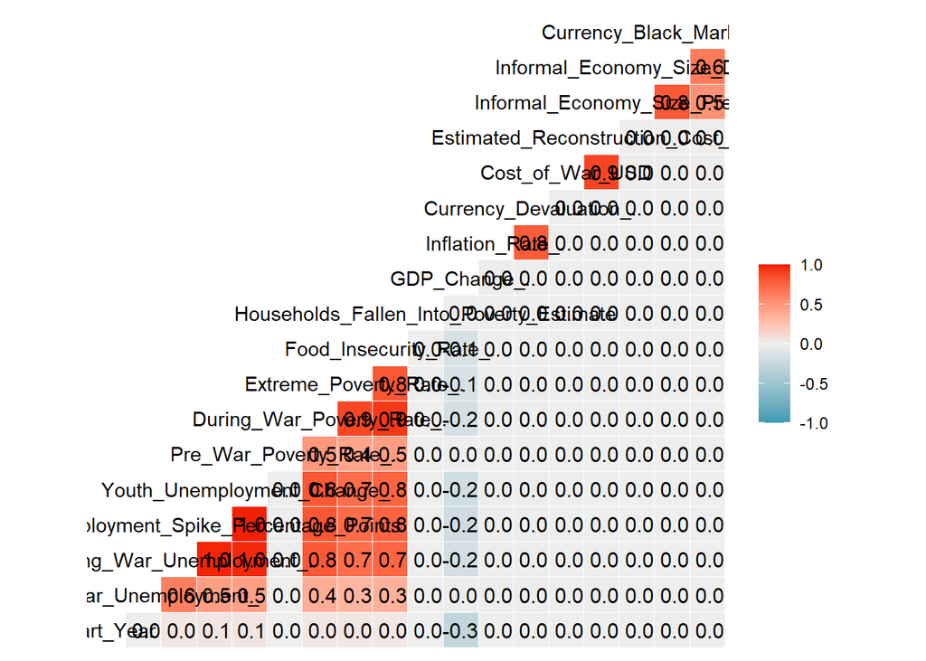

```r
GGally::ggcorr(data_filtered, label = T)
```

The correlation plot show very high correlation, as imaginable, for the economic indicators; more specifically regarding poverty rates and employment data. The correlation presents in clusters, strongly affecting the economic variables, which are redundant in some cases, but then not present among the other numeric observations.  
For the purpose of this research, I will most likely have to remove some of this highly correlated variables in order to reduce multicollinearity.

### - feature engineering

In order to reduce multicollinearity among economic variables and work with a cleaner data set, I will remove the redundant variables, and perform encoding and transformations where needed.

The data set presented some variables that measure change as two separate variables - divided in before and during the war. In order to capture the change while accounting for multicollinearity, one unique variable indicating the difference between pre and during war times will be created. The difference will be created for:

- poverty
- unemployment
- informal economy size

```r
data_clean <- data_filtered |>
  mutate(
    poverty = During_War_Poverty_Rate_. - Pre_War_Poverty_Rate_.,
    informal_economy = Informal_Economy_Size_During_War_. - Informal_Economy_Size_Pre_War_.,
    unemployment = During_War_Unemployment_. - Pre_War_Unemployment_.
  ) |>
  dplyr::select(-c(During_War_Poverty_Rate_., Pre_War_Poverty_Rate_.,
            Unemployment_Spike_Percentage_Points, Pre_War_Unemployment_.,
            During_War_Unemployment_., Informal_Economy_Size_Pre_War_.,
            Informal_Economy_Size_During_War_., Extreme_Poverty_Rate_.))
```

Transforming and standardizing the numeric variables, ready for modelling:

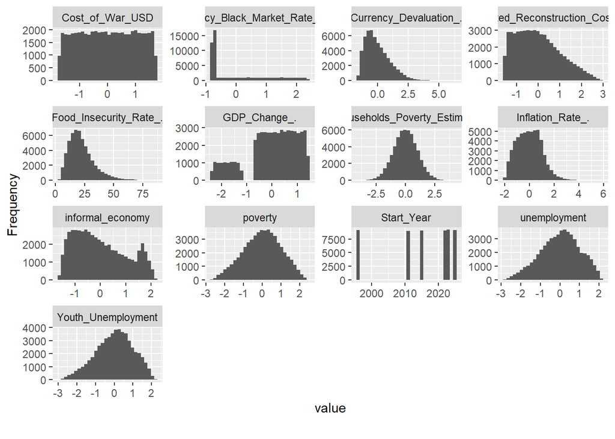

```r
data_clean <- data_clean |>
  mutate(
    Households_Poverty_Estimate = log1p(Households_Fallen_Into_Poverty_Estimate),
    Youth_Unemployment          = log1p(Youth_Unemployment_Change_.),
    poverty                     = log1p(poverty),
    unemployment                = log1p(unemployment)) |>
  dplyr::select(-c(Households_Fallen_Into_Poverty_Estimate,
                   Youth_Unemployment_Change_.))

#scale
cols_to_scale <- c("GDP_Change_.", "Inflation_Rate_.", "Currency_Devaluation_.",
                   "Cost_of_War_USD", "Estimated_Reconstruction_Cost_USD",
                   "Currency_Black_Market_Rate_Gap_.", "informal_economy",
                   "Households_Poverty_Estimate", "Youth_Unemployment",
                   "poverty", "unemployment")

data_clean <- data_clean |>
  mutate(across(all_of(cols_to_scale), ~ as.numeric(scale(.))))

#check distribution
plot_histogram(data_clean)
```

The variable indicating the primary goods sold at the black market will be divided into 6 binary categories; each of them corresponding to one type of good that is among the major type sold in the black market.

Similarly, the ‘war_profiteering_documented’ variable will be turned into a dummy variable, since the possible values are Yes and No.

```r
data_clean <- data_clean |>
  mutate(
    food     = as.integer(str_detect(Primary_Black_Market_Goods, "food")),
    fuel     = as.integer(str_detect(Primary_Black_Market_Goods, "fuel")),
    medicine = as.integer(str_detect(Primary_Black_Market_Goods, "medicine")),
    weapons  = as.integer(str_detect(Primary_Black_Market_Goods, "weapons")),
    water    = as.integer(str_detect(Primary_Black_Market_Goods, "water")),
    currency = as.integer(str_detect(Primary_Black_Market_Goods, "currency"))
    ) |>
  dplyr::select(-Primary_Black_Market_Goods)
```

Lastly, the ‘Black_Market_Activity_level’ and ‘war_Profiteering_Documented’ variable will be turned into factors.

```r
data_clean <- data_clean |>
  mutate(Black_Market_Activity_Level = factor(
    Black_Market_Activity_Level, levels = c("Low", "Moderate", "High",
                                            "Dominant")),
    War_Profiteering_Documented = factor(War_Profiteering_Documented,
    levels = c("No", "Yes"))
  )
```

The final data set that I will work with, will then have 25 variables and over 50.000 observations.

## Classification Model: explanation

For this first classification model, I will explore the variables that influence my target variable, documented war profiteering.

For this first part of the classification models, I will use the probabilistic learning methods and Knn. My target variable is binary, and I will start with a simple logistic model.

First of all, check for the dependent variable’s distribution among classes.

```r
table(data_clean$War_Profiteering_Documented)
```

```
##
##    No   Yes
## 16346 38132
```

```r
prop.table(table(data_clean$War_Profiteering_Documented))
```

```
##
##        No       Yes
## 0.3000477 0.6999523
```

From these first glance at the target variable’s distribution, I can already notice that my classes are not balanced, with about 70% of the observations belonging to the ‘yes’ class.

Now for the models, I will start with a simple logistic regression, to then move forward with more complex methods, such as LDA and decision trees.

### - logistic regression

A first logistic regression will be performed, to then be followed by a stepwise selection by AIC, to keep the most relevant predictors.

```r
data_idx <- createDataPartition(data_clean$War_Profiteering_Documented,
                                p = 0.7, list = FALSE)
data_train <- data_clean[data_idx, ]
data_test  <- data_clean[-data_idx, ]

cat("Train:", nrow(data_train), "| Test:", nrow(data_test), "\n")
```

```
## Train: 38136 | Test: 16342
```

```r
#logistic regression
logit_full  <- glm(War_Profiteering_Documented ~ .,
                   family = binomial(link = "logit"),
                   data = data_train, trace = FALSE)

logit_step  <- step(logit_full, direction = "both", trace = 0)
```

## Classification Model: modelling and prediction

To improve the prediction power and to test different models, LDA, QDA, Naive Bayes and Knn methods will be adopted. Further analysis will rely on decision trees, random forest and bagging methods, cost-sensitive analysis, and a simple neural network.

### - LDA, Naive-Bayes and Knn

```r
set.seed(240603)
#stepwise-selected predictors
stepwise_formula <- formula(logit_step)

#LDA
lda <- MASS::lda(War_Profiteering_Documented ~ ., data = data_train)
lda_pred <- predict(lda, newdata = data_test)$class

#QDA
qda <- MASS::qda(stepwise_formula, data = data_train)
qda_pred <- predict(qda, newdata = data_test)$class

#Naive Bayes
nb   <- e1071::naiveBayes(War_Profiteering_Documented ~ ., data = data_train)
nb_pred <- predict(nb, newdata = data_test)

#k-NN: Scaling + model predictions
#using the numeric columns in my data
numeric_cols <- c("GDP_Change_.", "Inflation_Rate_.", "poverty",
                  "unemployment", "Food_Insecurity_Rate_.",
                  "informal_economy", "Currency_Devaluation_.",
                  "Currency_Black_Market_Rate_Gap_.")

train_scaled <- scale(data_train[, numeric_cols])
test_scaled <- scale(
  data_test[, numeric_cols],
  center = attr(train_scaled, "scaled:center"),
  scale = attr(train_scaled, "scaled:scale")
)

#k-NN predictions for different k values
knn_pred_k1 <- class::knn(
  train = train_scaled,
  test  = test_scaled,
  cl    = data_train$War_Profiteering_Documented,
  k     = 1
)

knn_pred_k5 <- class::knn(
  train = train_scaled,
  test  = test_scaled,
  cl    = data_train$War_Profiteering_Documented,
  k     = 5
)

knn_pred_k20 <- class::knn(
  train = train_scaled,
  test  = test_scaled,
  cl    = data_train$War_Profiteering_Documented,
  k     = 20
)
```

The confusion matrices will be obtained and the summary tables as well, to compare and evaluate the different methods.

```r
#specifying the positive class
cm_lda <- confusionMatrix(lda_pred, data_test$War_Profiteering_Documented,
                          positive = "Yes")
cm_nb <- confusionMatrix(nb_pred,  data_test$War_Profiteering_Documented,
                          positive = "Yes")
cm_knn_k1 <- confusionMatrix(knn_pred_k1,  data_test$War_Profiteering_Documented,
                               positive = "Yes")
cm_knn_k5 <- confusionMatrix(knn_pred_k5,  data_test$War_Profiteering_Documented,
                               positive = "Yes")
cm_knn_k20 <- confusionMatrix(knn_pred_k20, data_test$War_Profiteering_Documented,
                               positive = "Yes")


cm_lda
```

```
## Confusion Matrix and Statistics
##
##           Reference
## Prediction    No   Yes
##        No      0     0
##        Yes  4903 11439
##
##                Accuracy : 0.7
##                  95% CI : (0.6929, 0.707)
##     No Information Rate : 0.7
##     P-Value [Acc > NIR] : 0.5039
##
##                   Kappa : 0
##
##  Mcnemar's Test P-Value : <2e-16
##
##             Sensitivity : 1.0
##             Specificity : 0.0
##          Pos Pred Value : 0.7
##          Neg Pred Value : NaN
##              Prevalence : 0.7
##          Detection Rate : 0.7
##    Detection Prevalence : 1.0
##       Balanced Accuracy : 0.5
##
##        'Positive' Class : Yes
##
```

```r
cm_nb
```

```
## Confusion Matrix and Statistics
##
##           Reference
## Prediction    No   Yes
##        No      0     0
##        Yes  4903 11439
##
##                Accuracy : 0.7
##                  95% CI : (0.6929, 0.707)
##     No Information Rate : 0.7
##     P-Value [Acc > NIR] : 0.5039
##
##                   Kappa : 0
##
##  Mcnemar's Test P-Value : <2e-16
##
##             Sensitivity : 1.0
##             Specificity : 0.0
##          Pos Pred Value : 0.7
##          Neg Pred Value : NaN
##              Prevalence : 0.7
##          Detection Rate : 0.7
##    Detection Prevalence : 1.0
##       Balanced Accuracy : 0.5
##
##        'Positive' Class : Yes
##
```

```r
cm_knn_k1
```

```
## Confusion Matrix and Statistics
##
##           Reference
## Prediction   No  Yes
##        No  1428 3456
##        Yes 3475 7983
##
##                Accuracy : 0.5759
##                  95% CI : (0.5683, 0.5835)
##     No Information Rate : 0.7
##     P-Value [Acc > NIR] : 1.0000
##
##                   Kappa : -0.0109
##
##  Mcnemar's Test P-Value : 0.8288
##
##             Sensitivity : 0.6979
##             Specificity : 0.2913
##          Pos Pred Value : 0.6967
##          Neg Pred Value : 0.2924
##              Prevalence : 0.7000
##          Detection Rate : 0.4885
##    Detection Prevalence : 0.7011
##       Balanced Accuracy : 0.4946
##
##        'Positive' Class : Yes
##
```

```r
cm_knn_k5
```

```
## Confusion Matrix and Statistics
##
##           Reference
## Prediction   No  Yes
##        No   828 1840
##        Yes 4075 9599
##
##                Accuracy : 0.638
##                  95% CI : (0.6306, 0.6454)
##     No Information Rate : 0.7
##     P-Value [Acc > NIR] : 1
##
##                   Kappa : 0.0092
##
##  Mcnemar's Test P-Value : <2e-16
##
##             Sensitivity : 0.8391
##             Specificity : 0.1689
##          Pos Pred Value : 0.7020
##          Neg Pred Value : 0.3103
##              Prevalence : 0.7000
##          Detection Rate : 0.5874
##    Detection Prevalence : 0.8367
##       Balanced Accuracy : 0.5040
##
##        'Positive' Class : Yes
##
```

```r
cm_knn_k20
```

```
## Confusion Matrix and Statistics
##
##           Reference
## Prediction    No   Yes
##        No    176   375
##        Yes  4727 11064
##
##                Accuracy : 0.6878
##                  95% CI : (0.6806, 0.6949)
##     No Information Rate : 0.7
##     P-Value [Acc > NIR] : 0.9997
##
##                   Kappa : 0.0042
##
##  Mcnemar's Test P-Value : <2e-16
##
##             Sensitivity : 0.9672
##             Specificity : 0.0359
##          Pos Pred Value : 0.7007
##          Neg Pred Value : 0.3194
##              Prevalence : 0.7000
##          Detection Rate : 0.6770
##    Detection Prevalence : 0.9663
##       Balanced Accuracy : 0.5016
##
##        'Positive' Class : Yes
##
```

```r
#summary tables
summary <- tibble(
  Method = c("LDA", "Naive Bayes", "k-NN (k=1)",
             "k-NN (k=5)", "k-NN (k=20)"),
  Accuracy = c(
    as.numeric(cm_lda$overall["Accuracy"]),
    as.numeric(cm_nb$overall["Accuracy"]),
    as.numeric(cm_knn_k1$overall["Accuracy"]),
    as.numeric(cm_knn_k5$overall["Accuracy"]),
    as.numeric(cm_knn_k20$overall["Accuracy"])
  )
)

knitr::kable(summary, digits = 3)
```

| Method | Accuracy |
| --- | --- |
| LDA | 0.700 |
| Naive Bayes | 0.700 |
| k-NN (k=1) | 0.576 |
| k-NN (k=5) | 0.638 |
| k-NN (k=20) | 0.688 |

The Knn models show that, as k increases, sensitivity rises and specificity collapses. The models have a tendency to classify only the positive class. The models minimize errors. The classes’ imbalance is the main cause of the model’s predictive bias, that steers them towards classifying everything to the ‘Yes’ class.

### - decision threshold and cost-sensitive analysis

Given the results of the previous analysis, class imbalance needs to be addressed through threshold adjustment and, if needed, cost sensitive analysis.

When predicting war profiteering, flagging an expense as a false negative - so failing to identify an instance of war profiteering - is more costly than mistaking something as profiteering when it isn’t; a false alarm (false positive). Therefore, when doing cost-sensitive analysis and determining the matrix, missing profiteering will have to be more costly than a false positive - which is still costly but less damaging.

Let’s first try by adjusting the decision threshold:

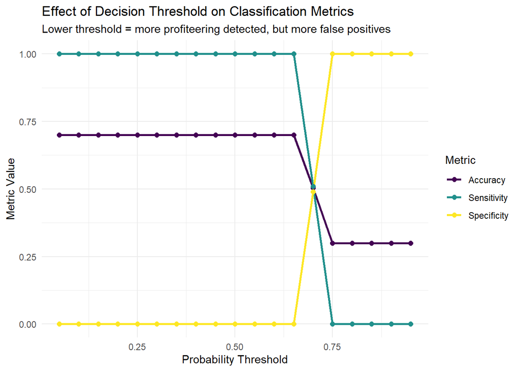

```r
#profiteering as a numeric vector - from the stepwise logistic regression
probs_logit <- predict(logit_step, newdata = data_test, type = "response")


#evaluate different thresholds
thresholds <- seq(0.05, 0.95, by = 0.05)
threshold_results <- data.frame()

for (thresh in thresholds) {
  pred <- factor(
    ifelse(probs_logit > thresh, "Yes", "No"), #yes = war profiteering
    levels = c("No", "Yes")
  )

  cm <- confusionMatrix(pred, data_test$War_Profiteering_Documented,
                        positive = "Yes")

  threshold_results <- rbind(threshold_results, data.frame(
    Threshold   = thresh,
    Accuracy    = as.numeric(cm$overall["Accuracy"]),
    Sensitivity = as.numeric(cm$byClass["Sensitivity"]),
    Specificity = as.numeric(cm$byClass["Specificity"])
  ))
}

#visualization
threshold_results |>
  pivot_longer(cols = -Threshold, names_to = "Metric", values_to = "Value") |>
  ggplot(aes(x = Threshold, y = Value, color = Metric)) +
  geom_line(linewidth = 1) +
  geom_point(size = 2) +
  labs(
    title = "Effect of Decision Threshold on Classification Metrics",
    subtitle = "Lower threshold = more profiteering detected, but more false positives",
    x = "Probability Threshold", y = "Metric Value"
  ) +
  theme_minimal() +
  scale_color_viridis_d()
```

This graphs shows that the logistic model predicts everything as ‘Yes’ until the 70% threshold is reached, point at which the predictions drastically switch to ‘No’. The logistic model does not seem to have a good discriminatory power to rightfully classify the observations. No threshold produces a meaningful separation between classes. This finding suggests that threshold adjustment is not enough to correct the model’s classification power, therefore leading to cost-sensitive learning.

Now cost-sensitive learning will be applied, but the first step is to define some helper functions:

```r
#decision threshold from the cost matrix in binary classification
#c00: TN cost, c01: FP cost, c10: FN cost, c11: TP cost
theoretical_threshold <- function(c01, c10, c00 = 0, c11 = 0) {
  numerator <- c01 - c00
  denominator <- (c01 - c00) + (c10 - c11)

  if (denominator <= 0) {
    stop("Invalid costs: denominator must be positive.")
  }

  numerator / denominator
}

#expected cost using a cost matrix; rows = actual class, columns = predicted class
expected_cost <- function(pred, actual, cost_matrix, normalize = TRUE) {

  actual <- factor(actual, levels = rownames(cost_matrix))
  pred <- factor(pred, levels = colnames(cost_matrix))

  cm <- table(actual, pred)
  total_cost <- sum(cm * cost_matrix)

  if (normalize) total_cost / sum(cm) else total_cost
}
```

Defining the cost matrix:

```r
#rows = actual class, columns = predicted class
cost_matrix <- matrix(c(
  0,  10,           #false positive; false alarm: TN = 0, FP = 10
  90, 0            #actual war profiteering: FN = 90, TP = 0
), nrow = 2, byrow = TRUE,
dimnames = list(
  Actual = c("No", "Yes"),
  Predicted = c("No", "Yes")
))

cat("Cost Matrix:\n")
```

```
## Cost Matrix:
```

```r
print(cost_matrix)
```

```
##       Predicted
## Actual No Yes
##    No   0  10
##    Yes 90   0
```

Theoretical threshold derivation and evaluation:

```r
c00 <- cost_matrix["No", "No"]   # TN = 0
c01 <- cost_matrix["No", "Yes"]  # FP = 10
c10 <- cost_matrix["Yes", "No"]  # FN = 90
c11 <- cost_matrix["Yes", "Yes"] # TP = 0

p_star_theory <- theoretical_threshold(c01 = c01, c10 = c10, c00 = c00, c11 = c11)
cat(sprintf("Theoretical threshold: %.3f\n", p_star_theory))
```

```
## Theoretical threshold: 0.100
```

This first theoretical threshold is 0.10, meaning that any value assigned a probability of profiteering higher than 10% will be flagged. The threshold is low because missing a real case of war profiteering (also given the strongly negative humanitarian effects that these profits usually equal to in societies at war) is more costly and dangerous than mis-identifing a false positive case.

Now for the optimal threshold:

```r
# Sweep thresholds and compute expected cost
cost_results <- data.frame()

for (thresh in thresholds) {
  pred <- factor(
    ifelse(probs_logit > thresh, "Yes", "No"),
    levels = c("No", "Yes")
  )

  cost_val <- expected_cost(
    pred        = pred,
    actual      = data_test$War_Profiteering_Documented,
    cost_matrix = cost_matrix,
    normalize   = TRUE
  )

  cost_results <- rbind(cost_results, data.frame(
    Threshold     = thresh,
    Expected_Cost = cost_val
  ))
}

#optimal threshold
optimal_thresh <- cost_results$Threshold[which.min(cost_results$Expected_Cost)]

cat("Cost-optimal threshold:", optimal_thresh, "\n")
```

```
## Cost-optimal threshold: 0.05
```

```r
cat("Minimum expected cost:", round(min(cost_results$Expected_Cost), 3), "\n")
```

```
## Minimum expected cost: 3
```

```r
cat("Theoretical threshold:", round(p_star_theory, 3), "\n")
```

```
## Theoretical threshold: 0.1
```

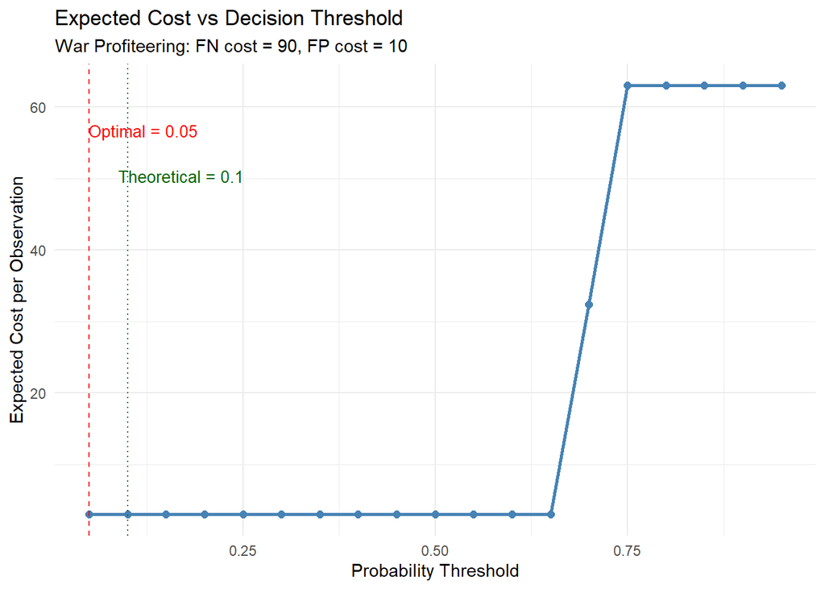

```r
#visualize
ggplot(cost_results, aes(x = Threshold, y = Expected_Cost)) +
  geom_line(color = "steelblue", linewidth = 1) +
  geom_point(color = "steelblue", size = 2) +
  geom_vline(xintercept = optimal_thresh, linetype = "dashed", color = "red") +
  geom_vline(xintercept = p_star_theory, linetype = "dotted", color = "darkgreen") +
  annotate("text", x = optimal_thresh + 0.07,
           y = max(cost_results$Expected_Cost) * 0.9,
           label = paste("Optimal =", optimal_thresh), color = "red", size = 3.5) +
  annotate("text", x = p_star_theory + 0.07,
           y = max(cost_results$Expected_Cost) * 0.8,
           label = paste("Theoretical =", round(p_star_theory, 2)),
           color = "darkgreen", size = 3.5) +
  labs(
    title = "Expected Cost vs Decision Threshold",
    subtitle = "War Profiteering: FN cost = 90, FP cost = 10",
    x = "Probability Threshold", y = "Expected Cost per Observation"
  ) +
  theme_minimal()
```

```r
cat("Cost-optimal threshold:", optimal_thresh, "\n")
```

```
## Cost-optimal threshold: 0.05
```

```r
cat("Minimum expected cost:", min(cost_results$Expected_Cost), "\n")
```

```
## Minimum expected cost: 3.000245
```

```r
cat("Theoretical threshold from cost matrix:", round(p_star_theory, 3), "\n")
```

```
## Theoretical threshold from cost matrix: 0.1
```

```r
train_x <- data_train |> dplyr::select(-War_Profiteering_Documented)
train_y <- data_train$War_Profiteering_Documented

train_down <- downSample(x = train_x, y = train_y, yname = "War_Profiteering_Documented")
train_up   <- upSample(x = train_x,   y = train_y, yname = "War_Profiteering_Documented")

ctrl_resample <- trainControl(method = "cv", number = 5, classProbs = TRUE)

logit_down <- train(War_Profiteering_Documented ~ ., data = train_down, method = "glm",
                    family = binomial(), trControl = ctrl_resample)
logit_up   <- train(War_Profiteering_Documented ~ ., data = train_up,   method = "glm",
                    family = binomial(), trControl = ctrl_resample)

prob_base <- probs_logit
prob_down <- predict(logit_down, data_test, type = "prob")[, "Yes"]
prob_up   <- predict(logit_up,   data_test, type = "prob")[, "Yes"]

pred_base <- factor(ifelse(prob_base >= 0.5, "Yes", "No"), levels = c("No", "Yes"))
pred_down <- factor(ifelse(prob_down >= 0.5, "Yes", "No"), levels = c("No", "Yes"))
pred_up   <- factor(ifelse(prob_up   >= 0.5, "Yes", "No"), levels = c("No", "Yes"))

cm_base <- confusionMatrix(pred_base, data_test$War_Profiteering_Documented, positive = "Yes")
cm_down <- confusionMatrix(pred_down, data_test$War_Profiteering_Documented, positive = "Yes")
cm_up   <- confusionMatrix(pred_up,   data_test$War_Profiteering_Documented, positive = "Yes")

resampling_results <- tibble(
  Strategy = c("No resampling", "Downsampling", "Oversampling"),
  Accuracy    = c(cm_base$overall["Accuracy"],    cm_down$overall["Accuracy"],    cm_up$overall["Accuracy"]),
  Sensitivity = c(cm_base$byClass["Sensitivity"], cm_down$byClass["Sensitivity"], cm_up$byClass["Sensitivity"]),
  Specificity = c(cm_base$byClass["Specificity"], cm_down$byClass["Specificity"], cm_up$byClass["Specificity"]),
  Precision   = c(cm_base$byClass["Precision"],   cm_down$byClass["Precision"],   cm_up$byClass["Precision"]),
  Expected_Cost = c(
    expected_cost(pred_base, data_test$War_Profiteering_Documented, cost_matrix),
    expected_cost(pred_down, data_test$War_Profiteering_Documented, cost_matrix),
    expected_cost(pred_up,   data_test$War_Profiteering_Documented, cost_matrix)
  )
)

knitr::kable(resampling_results, digits = 3,
             caption = "Resampling Strategies at Threshold 0.5")
```

Resampling Strategies at Threshold 0.5

| Strategy | Accuracy | Sensitivity | Specificity | Precision | Expected_Cost |
| --- | --- | --- | --- | --- | --- |
| No resampling | 0.700 | 1.000 | 0.000 | 0.700 | 3.000 |
| Downsampling | 0.499 | 0.491 | 0.517 | 0.703 | 33.507 |
| Oversampling | 0.503 | 0.507 | 0.493 | 0.700 | 32.566 |

Resampling produces a more balanced classifier; both downsampling and oversampling achieve almost equal sensitivity and specificity, around 0.50. The model does not default to the majority class, as it did previously. However, the expected cost rises sharply compared to the no-resampling baseline. In conclusion, cost-sensitive learning and balancing classes improved fairness of predictions but did not necessarily minimize expected cost under strongly asymmetric penalties.

Now I will move onto tree-based methods, which ideally better capture the non-linear structure of the data and achieve a more favorable balance between sensitivity and cost.

### - trees-based methods

```r
#tree
war_profiteering_tree <- tree(
  War_Profiteering_Documented ~ .,
  data    = train_down,
  control = tree.control(
    nobs    = nrow(train_down),
    mindev  = 0.001, #lower for high volume data
    minsize = 10
  )
)
summary(war_profiteering_tree)
```

```
##
## Classification tree:
## tree(formula = War_Profiteering_Documented ~ ., data = train_down,
##     control = tree.control(nobs = nrow(train_down), mindev = 0.001,
##         minsize = 10))
## Variables actually used in tree construction:
## character(0)
## Number of terminal nodes:  1
## Residual mean deviance:  1.386 = 31730 / 22880
## Misclassification error rate: 0.5 = 11443 / 22886
```

The decision tree, even when trained on the balanced downsampled data set and with a low splitting threshold, fails to find meaningful splits, therefore leading me to attempt more complex tree-structures, such as bagging random forest.

```r
p_war <- ncol(train_down) - 1

set.seed(240603)
war_bag <- randomForest(
  War_Profiteering_Documented ~ .,
  data       = train_down,
  mtry       = p_war,
  ntree      = 500,
  importance = TRUE
)
war_bag
```

```
##
## Call:
##  randomForest(formula = War_Profiteering_Documented ~ ., data = train_down,      mtry = p_war, ntree = 500, importance = TRUE)
##                Type of random forest: classification
##                      Number of trees: 500
## No. of variables tried at each split: 24
##
##         OOB estimate of  error rate: 50.34%
## Confusion matrix:
##       No  Yes class.error
## No  5747 5696   0.4977716
## Yes 5824 5619   0.5089574
```

```r
war_bag_pred <- predict(war_bag, newdata = data_test, type = "class")
cm_bag <- confusionMatrix(war_bag_pred, data_test$War_Profiteering_Documented,
                          positive = "Yes")
cm_bag
```

```
## Confusion Matrix and Statistics
##
##           Reference
## Prediction   No  Yes
##        No  2473 5678
##        Yes 2430 5761
##
##                Accuracy : 0.5039
##                  95% CI : (0.4962, 0.5116)
##     No Information Rate : 0.7
##     P-Value [Acc > NIR] : 1
##
##                   Kappa : 0.0067
##
##  Mcnemar's Test P-Value : <2e-16
##
##             Sensitivity : 0.5036
##             Specificity : 0.5044
##          Pos Pred Value : 0.7033
##          Neg Pred Value : 0.3034
##              Prevalence : 0.7000
##          Detection Rate : 0.3525
##    Detection Prevalence : 0.5012
##       Balanced Accuracy : 0.5040
##
##        'Positive' Class : Yes
##
```

Finally, random forest will be attempted, as well as the two methods’ comparison (bagging and random forest, as the decision tree did not give any significant result, producing only one node).

```r
set.seed(240603)

war_rf <- randomForest(
  War_Profiteering_Documented ~ .,
  data       = train_down,
  mtry       = floor(sqrt(p_war)),
  ntree      = 500,
  importance = TRUE
)
war_rf
```

```
##
## Call:
##  randomForest(formula = War_Profiteering_Documented ~ ., data = train_down,      mtry = floor(sqrt(p_war)), ntree = 500, importance = TRUE)
##                Type of random forest: classification
##                      Number of trees: 500
## No. of variables tried at each split: 4
##
##         OOB estimate of  error rate: 50%
## Confusion matrix:
##       No  Yes class.error
## No  5731 5712   0.4991698
## Yes 5730 5713   0.5007428
```

```r
war_rf_pred <- predict(war_rf, newdata = data_test, type = "class")
cm_rf <- confusionMatrix(war_rf_pred, data_test$War_Profiteering_Documented,
                         positive = "Yes")
cm_rf
```

```
## Confusion Matrix and Statistics
##
##           Reference
## Prediction   No  Yes
##        No  2440 5682
##        Yes 2463 5757
##
##                Accuracy : 0.5016
##                  95% CI : (0.4939, 0.5093)
##     No Information Rate : 0.7
##     P-Value [Acc > NIR] : 1
##
##                   Kappa : 8e-04
##
##  Mcnemar's Test P-Value : <2e-16
##
##             Sensitivity : 0.5033
##             Specificity : 0.4977
##          Pos Pred Value : 0.7004
##          Neg Pred Value : 0.3004
##              Prevalence : 0.7000
##          Detection Rate : 0.3523
##    Detection Prevalence : 0.5030
##       Balanced Accuracy : 0.5005
##
##        'Positive' Class : Yes
##
```

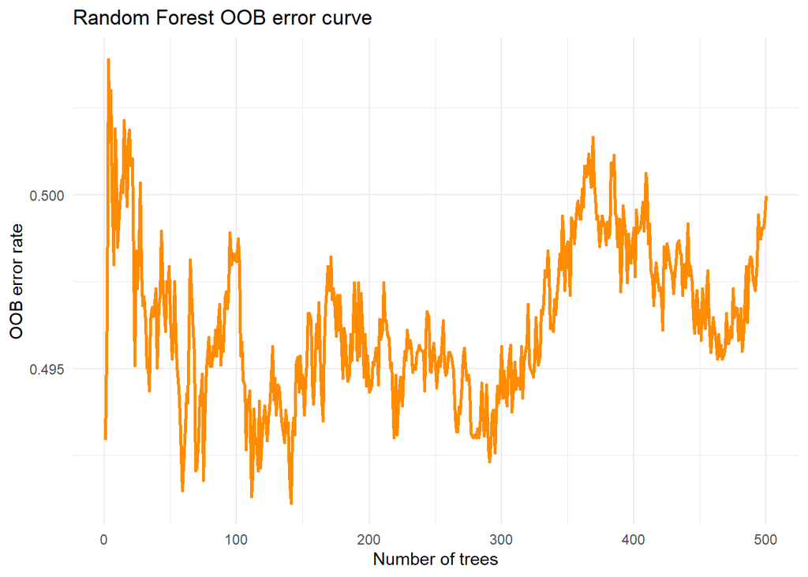

```r
#OOB curve
tibble(
  trees     = seq_len(nrow(war_rf$err.rate)),
  oob_error = war_rf$err.rate[, "OOB"]
) |>
  ggplot(aes(x = trees, y = oob_error)) +
  geom_line(color = "darkorange", linewidth = 1) +
  labs(title = "Random Forest OOB error curve",
       x = "Number of trees", y = "OOB error rate") +
  theme_minimal()
```

```r
#model comparison
extract_metrics <- function(cm, model_name) {
  tibble(
    Model               = model_name,
    Accuracy            = as.numeric(cm$overall["Accuracy"]),
    Sensitivity         = as.numeric(cm$byClass["Sensitivity"]),
    Specificity         = as.numeric(cm$byClass["Specificity"]),
    `Balanced Accuracy` = as.numeric(cm$byClass["Balanced Accuracy"])
  )
}

tree_results <- bind_rows(
  extract_metrics(cm_bag,    "Bagging"),
  extract_metrics(cm_rf,     "Random Forest")
)

knitr::kable(tree_results, digits = 3)
```

| Model | Accuracy | Sensitivity | Specificity | Balanced Accuracy |
| --- | --- | --- | --- | --- |
| Bagging | 0.504 | 0.504 | 0.504 | 0.504 |
| Random Forest | 0.502 | 0.503 | 0.498 | 0.500 |

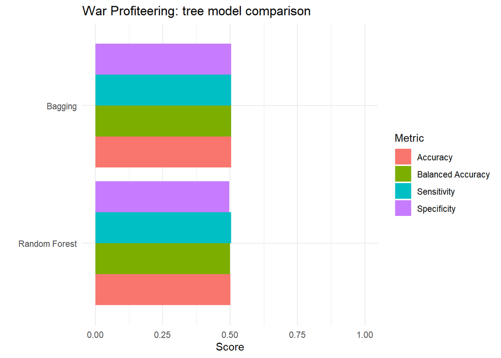

```r
tree_results |>
  pivot_longer(cols = -Model, names_to = "Metric", values_to = "Value") |>
  ggplot(aes(x = reorder(Model, Value), y = Value, fill = Metric)) +
  geom_col(position = "dodge") +
  coord_flip() +
  ylim(0, 1) +
  labs(title = "War Profiteering: tree model comparison", x = "", y = "Score") +
  theme_minimal()
```

Random forest has little to no difference compared to the bagging method, with accuracy, sensitivity, specificity and balanced accuracy all converging at approximately 0.50.

In conclusion, the economic indicators available in this data set do not contain sufficient predictive power to correctly classify documented war profiteering. War profiteering is most likely driven by contextual, institutional, and political factors that macroeconomic variables are not able to capture.

## Regression Model: explanation

For this first part of the regression model, the focus will be on a simple OLS regression model and its interpretation. The best subset selection will also be performed in this first part. The following part (modelling and prediction) will focus on different models, regularization models to be specific, and it will dive deeper into models’ evaluation and prediction power.

The target variable of this advanced regression model is ‘Food_Insecurity_Rate’, and because of the different type of analysis that this dependent variable will require, the ‘data_clean’ set will be used.

```r
set.seed(240603)
in_train <- createDataPartition(data_clean$Food_Insecurity_Rate_., p = 0.75, list = FALSE)
training <- data_clean[in_train, ]
testing  <- data_clean[-in_train, ]

cat("Training set:", nrow(training), "observations\n")
```

```
## Training set: 40860 observations
```

```r
cat("Testing set:", nrow(testing), "observations\n")
```

```
## Testing set: 13618 observations
```

Correlations.

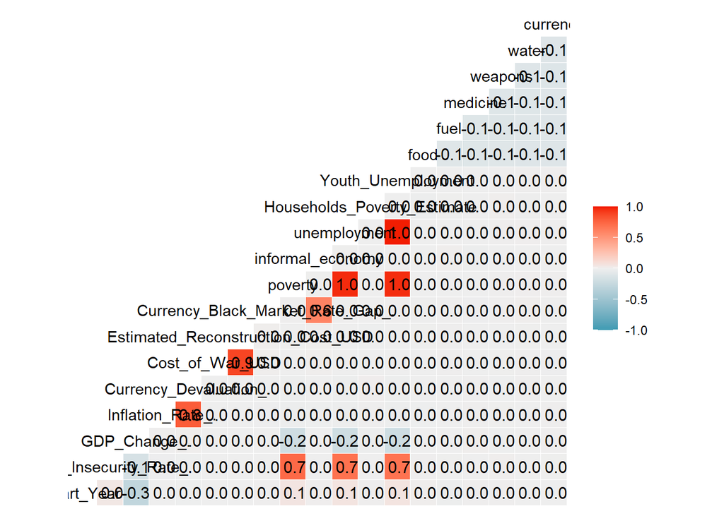

```r
GGally::ggcorr(training, label = T)
```

The data does not look strongly related, besides some variables that show very high values of correlation, such as poverty and unemployment. The variables representing the most sold goods in the black market show a very small negative correlation.

Now an initial regression set up will be created. It will rely on the OLS method to minimize the sum of squared residuals. The variables were already transformed, so I do not apply any kind of transformation here.

```r
linFit <- lm(Food_Insecurity_Rate_. ~ GDP_Change_. + Inflation_Rate_. +
  Currency_Devaluation_. + Cost_of_War_USD + Estimated_Reconstruction_Cost_USD +
  Currency_Black_Market_Rate_Gap_. + War_Profiteering_Documented +
  poverty + informal_economy + unemployment +
  Households_Poverty_Estimate + Youth_Unemployment +
  food + fuel + medicine + weapons + water + currency,
  data = training)

summary(linFit)
```

```
##
## Call:
## lm(formula = Food_Insecurity_Rate_. ~ GDP_Change_. + Inflation_Rate_. +
##     Currency_Devaluation_. + Cost_of_War_USD + Estimated_Reconstruction_Cost_USD +
##     Currency_Black_Market_Rate_Gap_. + War_Profiteering_Documented +
##     poverty + informal_economy + unemployment + Households_Poverty_Estimate +
##     Youth_Unemployment + food + fuel + medicine + weapons + water +
##     currency, data = training)
##
## Residuals:
##     Min      1Q  Median      3Q     Max
## -16.722  -5.537  -0.746   4.730  45.914
##
## Coefficients:
##                                    Estimate Std. Error t value Pr(>|t|)
## (Intercept)                       22.412782   0.113430 197.591  < 2e-16 ***
## GDP_Change_.                      -0.103147   0.037947  -2.718  0.00657 **
## Inflation_Rate_.                  -0.023695   0.061079  -0.388  0.69807
## Currency_Devaluation_.             0.065244   0.061145   1.067  0.28596
## Cost_of_War_USD                    0.108959   0.079801   1.365  0.17214
## Estimated_Reconstruction_Cost_USD -0.106473   0.079701  -1.336  0.18159
## Currency_Black_Market_Rate_Gap_.  -0.039680   0.046754  -0.849  0.39606
## War_Profiteering_DocumentedYes    -0.142875   0.081203  -1.759  0.07850 .
## poverty                           10.235237   0.141436  72.367  < 2e-16 ***
## informal_economy                   0.009607   0.046568   0.206  0.83656
## unemployment                       1.993018   0.403653   4.937 7.95e-07 ***
## Households_Poverty_Estimate        0.014532   0.037253   0.390  0.69648
## Youth_Unemployment                -4.292397   0.379287 -11.317  < 2e-16 ***
## food                               0.072847   0.082411   0.884  0.37673
## fuel                               0.106592   0.082662   1.289  0.19723
## medicine                           0.069499   0.082448   0.843  0.39927
## weapons                            0.143622   0.082540   1.740  0.08186 .
## water                             -0.067310   0.082239  -0.818  0.41310
## currency                          -0.005741   0.082261  -0.070  0.94436
## ---
## Signif. codes:  0 '***' 0.001 '**' 0.01 '*' 0.05 '.' 0.1 ' ' 1
##
## Residual standard error: 7.522 on 40841 degrees of freedom
## Multiple R-squared:  0.5363, Adjusted R-squared:  0.5361
## F-statistic:  2624 on 18 and 40841 DF,  p-value: < 2.2e-16
```

To gain a clearer perspective of the model’s performance, the linear model will also be evaluated through the testing set as well:

```r
pred_linFit <- predict(linFit, newdata = testing)
cat("Test R^2:", round(cor(testing$Food_Insecurity_Rate_., pred_linFit)^2, 3), "\n")
```

```
## Test R^2: 0.541
```

The R2 of the testing set corresponds to the training set’s one (54%), indicating that the model’s performance is stable.

### - best sub-set selection

Now, the predictions will be stored in a separate object and the set up for the cross-validation will be done.

```r
#store predictions against actual values
test_results <- data.frame(actual = testing$Food_Insecurity_Rate_.)

#model complexity
model_p <- c()

#helper function
register_model <- function(name, pred, p) {
  test_results[[name]] <<- as.numeric(pred)
  model_p[[name]] <<- as.integer(p)
}

#5-fold cross validation
ctrl <- trainControl(method = "repeatedcv", number = 5, repeats = 1)
```

Thorough this step, I have established data sets and functions that will help me later to categorize and compare the best model.

OLS baseline:

```r
register_model(
  name = "OLS_baseline",
  pred = predict(linFit, newdata = testing),
  p    = length(coef(linFit))
)
```

### - AIC

To gather a more complete understanding of the model’s performance, the AIC and BIC will be gathered and analyzed.

Given the big size of the data set, I will directly rely upon the forward selection method using the AIC. By doing this, the most relevant predictors will be kept and automatically selected by the AIC measure.

```r
forward_AIC <- ols_step_forward_aic(linFit)
forward_AIC
```

```
##
##
##                                           Stepwise Summary
## ---------------------------------------------------------------------------------------------------
## Step    Variable                          AIC           SBC           SBIC         R2       Adj. R2
## ---------------------------------------------------------------------------------------------------
##  0      Base Model                     312234.777    312252.013    196277.473    0.00000    0.00000
##  1      poverty                        281241.666    281267.519    165285.971    0.53166    0.53165
##  2      Youth_Unemployment             280885.932    280920.404    164930.271    0.53575    0.53572
##  3      unemployment                   280863.191    280906.281    164907.534    0.53603    0.53599
##  4      GDP_Change_.                   280857.651    280909.358    164901.995    0.53611    0.53607
##  5      War_Profiteering_Documented    280856.585    280916.910    164900.930    0.53615    0.53609
##  6      weapons                        280856.050    280924.994    164900.397    0.53618    0.53611
## ---------------------------------------------------------------------------------------------------
##
## Final Model Output
## ------------------
##
##                           Model Summary
## ------------------------------------------------------------------
## R                       0.732       RMSE                    7.521
## R-Squared               0.536       MSE                    56.563
## Adj. R-Squared          0.536       Coef. Var              33.574
## Pred R-Squared          0.536       AIC                280856.050
## MAE                     5.977       SBC                280924.994
## ------------------------------------------------------------------
##  RMSE: Root Mean Square Error
##  MSE: Mean Square Error
##  MAE: Mean Absolute Error
##  AIC: Akaike Information Criteria
##  SBC: Schwarz Bayesian Criteria
##
##                                    ANOVA
## ----------------------------------------------------------------------------
##                    Sum of
##                   Squares           DF    Mean Square       F          Sig.
## ----------------------------------------------------------------------------
## Regression    2671672.440            6     445278.740    7870.954    0.0000
## Residual      2311152.059        40853         56.572
## Total         4982824.499        40859
## ----------------------------------------------------------------------------
##
##                                             Parameter Estimates
## ------------------------------------------------------------------------------------------------------------
##                          model      Beta    Std. Error    Std. Beta       t        Sig      lower     upper
## ------------------------------------------------------------------------------------------------------------
##                    (Intercept)    22.477         0.073                 309.157    0.000    22.334    22.619
##                        poverty    10.234         0.141        0.926     72.365    0.000     9.956    10.511
##             Youth_Unemployment    -4.287         0.379       -0.388    -11.306    0.000    -5.031    -3.544
##                   unemployment     1.989         0.404        0.180      4.929    0.000     1.198     2.780
##                   GDP_Change_.    -0.103         0.038       -0.009     -2.719    0.007    -0.178    -0.029
## War_Profiteering_DocumentedYes    -0.143         0.081       -0.006     -1.761    0.078    -0.302     0.016
##                        weapons     0.126         0.079        0.005      1.592    0.111    -0.029     0.280
## ------------------------------------------------------------------------------------------------------------
```

```r
register_model(
  name = "forward_AIC",
  pred = predict(forward_AIC$model, newdata = testing),
  p = length(coef(forward_AIC$model))
)
postResample(pred = test_results$forward_AIC, obs = test_results$actual)
```

```
##      RMSE  Rsquared       MAE
## 7.5439116 0.5406637 5.9896793
```

This first forward stepwise method only selected 6 relevant predictors for the target variable, food insecurity. The most important predictor is poverty, 1-unit increase in poverty is associated with about 10% increase in food insecurity. Unemployment is also a relevant indicator, although not as strong as poverty. The presence of a highly negative beta for youth unemployment is most likely related to the possible presence of multicollinearity between the variables.

The model’s R squared confirms the 54% variance explained, maintaining stable compared to the original model.

Now the same process will be done, but a layer of specificity will be added to provide more stable results.

```r
both_AIC <- ols_step_both_aic(linFit)
both_AIC
```

```
##
##
##                                             Stepwise Summary
## -------------------------------------------------------------------------------------------------------
## Step    Variable                              AIC           SBC           SBIC         R2       Adj. R2
## -------------------------------------------------------------------------------------------------------
##  0      Base Model                         312234.777    312252.013    196277.473    0.00000    0.00000
##  1      poverty (+)                        281241.666    281267.519    165285.971    0.53166    0.53165
##  2      Youth_Unemployment (+)             280885.932    280920.404    164930.271    0.53575    0.53572
##  3      unemployment (+)                   280863.191    280906.281    164907.534    0.53603    0.53599
##  4      GDP_Change_. (+)                   280857.651    280909.358    164901.995    0.53611    0.53607
##  5      War_Profiteering_Documented (+)    280856.585    280916.910    164900.930    0.53615    0.53609
##  6      weapons (+)                        280856.050    280924.994    164900.397    0.53618    0.53611
## -------------------------------------------------------------------------------------------------------
##
## Final Model Output
## ------------------
##
##                           Model Summary
## ------------------------------------------------------------------
## R                       0.732       RMSE                    7.521
## R-Squared               0.536       MSE                    56.563
## Adj. R-Squared          0.536       Coef. Var              33.574
## Pred R-Squared          0.536       AIC                280856.050
## MAE                     5.977       SBC                280924.994
## ------------------------------------------------------------------
##  RMSE: Root Mean Square Error
##  MSE: Mean Square Error
##  MAE: Mean Absolute Error
##  AIC: Akaike Information Criteria
##  SBC: Schwarz Bayesian Criteria
##
##                                    ANOVA
## ----------------------------------------------------------------------------
##                    Sum of
##                   Squares           DF    Mean Square       F          Sig.
## ----------------------------------------------------------------------------
## Regression    2671672.440            6     445278.740    7870.954    0.0000
## Residual      2311152.059        40853         56.572
## Total         4982824.499        40859
## ----------------------------------------------------------------------------
##
##                                             Parameter Estimates
## ------------------------------------------------------------------------------------------------------------
##                          model      Beta    Std. Error    Std. Beta       t        Sig      lower     upper
## ------------------------------------------------------------------------------------------------------------
##                    (Intercept)    22.477         0.073                 309.157    0.000    22.334    22.619
##                        poverty    10.234         0.141        0.926     72.365    0.000     9.956    10.511
##             Youth_Unemployment    -4.287         0.379       -0.388    -11.306    0.000    -5.031    -3.544
##                   unemployment     1.989         0.404        0.180      4.929    0.000     1.198     2.780
##                   GDP_Change_.    -0.103         0.038       -0.009     -2.719    0.007    -0.178    -0.029
## War_Profiteering_DocumentedYes    -0.143         0.081       -0.006     -1.761    0.078    -0.302     0.016
##                        weapons     0.126         0.079        0.005      1.592    0.111    -0.029     0.280
## ------------------------------------------------------------------------------------------------------------
```

```r
register_model(
  name = "both_AIC",
  pred = predict(both_AIC$model, newdata = testing),
  p = length(coef(both_AIC$model))
)
postResample(pred = test_results$both_AIC, obs = test_results$actual)
```

```
##      RMSE  Rsquared       MAE
## 7.5439116 0.5406637 5.9896793
```

This model does not show any significant results, compared to the previous attempt.

Last stepwise selection attempt using a different method:

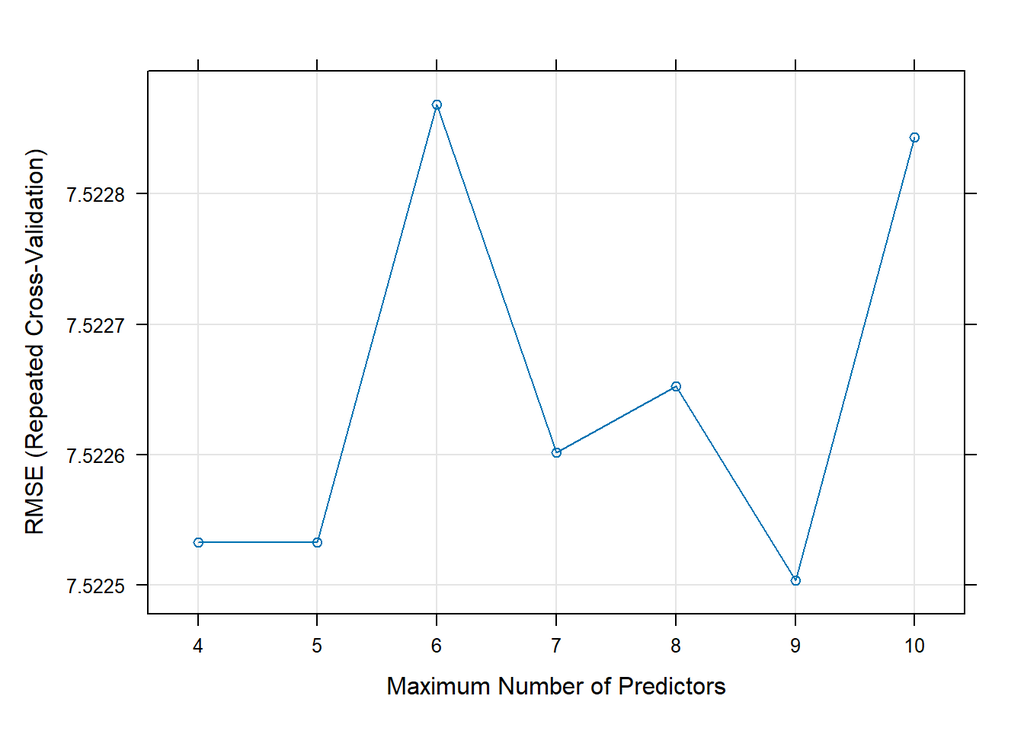

```r
for_tune <- train(Food_Insecurity_Rate_. ~ GDP_Change_. + Inflation_Rate_. +
                  Currency_Devaluation_. + Cost_of_War_USD +
                  Estimated_Reconstruction_Cost_USD +
                  Currency_Black_Market_Rate_Gap_. + War_Profiteering_Documented +
                  poverty + informal_economy + unemployment +
                  Households_Poverty_Estimate + Youth_Unemployment +
                 food + fuel + medicine + weapons + water + currency,
                 data = training,
                 method = "leapForward",
                 preProc = c('nzv','scale', 'center'),
                 tuneGrid = expand.grid(nvmax = 4:10),
                 trControl = ctrl)

plot(for_tune)
```

```r
cat("Best number of variables:", for_tune$bestTune$nvmax, "\n")
```

```
## Best number of variables: 9
```

```r
coef(for_tune$finalModel, for_tune$bestTune$nvmax)
```

```
##                    (Intercept)                   GDP_Change_.
##                    22.40244028                    -0.10356183
##         Currency_Devaluation_. War_Profiteering_DocumentedYes
##                     0.04669104                    -0.06579221
##                        poverty                   unemployment
##                    10.22885889                     1.99353588
##             Youth_Unemployment                           fuel
##                    -4.29157000                     0.04203363
##                        weapons                          water
##                     0.05994950                    -0.03991252
```

```r
register_model(
  name = "forward_CV",
  pred = predict(for_tune, testing),
  p = length(coef(for_tune$finalModel, for_tune$bestTune$nvmax))
)
postResample(pred = test_results$forward_CV, obs = test_results$actual)
```

```
##      RMSE  Rsquared       MAE
## 7.5441553 0.5406342 5.9893089
```

This model specifically identifies the best number of predictors, which here seems to be 9. Compared to the previous cases, this method adds currency devaluation, water, and fuel. The R2 is unchanged.

Overall, for this initial OLS model, the number of predictors that are suggested to understand the changes and influences on food insecurity in war countries is low - ranging from 6 to 9 relevant variables.

## Regression Model: modelling and prediction

In order to effectively do model comparison, the Ridge and Lasso penalized regressions, and finally Principal Component Regression and Partial Least Squares.

### - Ridge Regression

All coefficients will be shrunk close to zero.

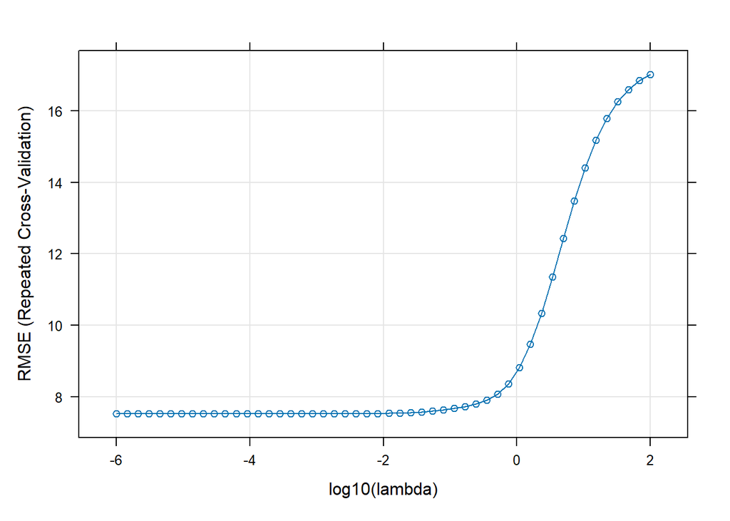

```r
set.seed(240603)

ModelF <- Food_Insecurity_Rate_. ~ GDP_Change_. + Inflation_Rate_. +
  Currency_Devaluation_. + Cost_of_War_USD + Estimated_Reconstruction_Cost_USD +
  Currency_Black_Market_Rate_Gap_. + War_Profiteering_Documented +
  poverty + informal_economy + unemployment +
  Households_Poverty_Estimate + Youth_Unemployment +
  food + fuel + medicine + weapons + water + currency

ridge_grid <- expand.grid(lambda = 10^seq(-6, 2, length.out = 50)) #lambda values

ridge_tune <- train(ModelF,
                    data = training,
                    method = "ridge",
                    preProc = c("scale", "center"),
                    tuneGrid = ridge_grid,
                    trControl = ctrl)

plot(ridge_tune, xTrans = log10, xlab = "log10(lambda)")
```

```r
cat("Best lambda for Ridge:", ridge_tune$bestTune$lambda, "\n")
```

```
## Best lambda for Ridge: 4.291934e-05
```

```r
register_model(
  name = "ridge",
  pred = predict(ridge_tune, testing),
  p = length(attr(ridge_tune$terms, "term.labels"))
)
postResample(pred = test_results$ridge, obs = test_results$actual)
```

```
##      RMSE  Rsquared       MAE
## 7.5443197 0.5406146 5.9892440
```

The model’s metrics are also similar to the ones got with the original OLS, with a stable R2 at 0.54. This confirms that Ridge did not apply such a strong penalization, and the result is therefore quite similar to the original baseline OLS model.

### - Lasso regression

This shrinks the coefficients to zero.

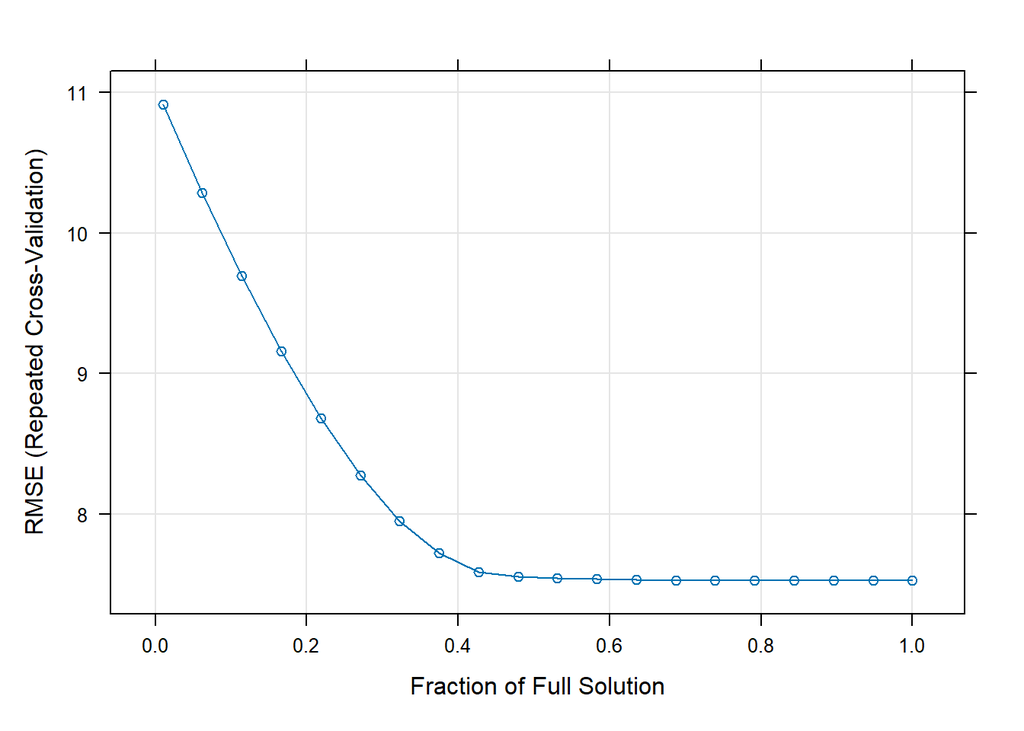

```r
lasso_grid <- expand.grid(fraction = seq(0.01, 1, length.out = 20))

lasso_tune <- train(ModelF,
                    data = training,
                    method = "lasso",
                    preProc = c("scale", "center"),
                    tuneGrid = lasso_grid,
                    trControl = ctrl)

plot(lasso_tune)
```

```r
cat("Best lambda for Lasso:", lasso_tune$bestTune$fraction, "\n")
```

```
## Best lambda for Lasso: 1
```

```r
register_model(
  name = "lasso",
  pred = predict(lasso_tune, testing),
  p = length(attr(lasso_tune$terms, "term.labels"))
)
postResample(pred = test_results$lasso, obs = test_results$actual)
```

```
##      RMSE  Rsquared       MAE
## 7.5443106 0.5406153 5.9892455
```

The best lambda according to this model is 1, and the model’s metrics are all the same for the original OLS model. Similarly to Ridge’s case, the best lambda suggests the coefficients were barely shrunk and that the penalization methods, in this case, did not improve performance.

### - PCR and PLS

PCR and PLS reduce the dimensionality of the model. First, the data for these models will be set up.

```r
set.seed(240603)

#data matrices with the full model formula
x_train_dr <- model.matrix(ModelF, data = training)[, -1, drop = FALSE]
x_test_dr  <- model.matrix(ModelF, data = testing)[, -1, drop = FALSE]

#standardize the data
pp <- preProcess(x_train_dr, method = c("center", "scale"))
x_train_dr <- predict(pp, x_train_dr)
x_test_dr  <- predict(pp, x_test_dr)

pcr_train_df <- data.frame(Food_Insecurity_Rate_. =
                           training$Food_Insecurity_Rate_., x_train_dr,
                           check.names = FALSE)
pcr_test_df  <- data.frame(x_test_dr, check.names = FALSE)
```

Now, the Principal Components Regression can run.

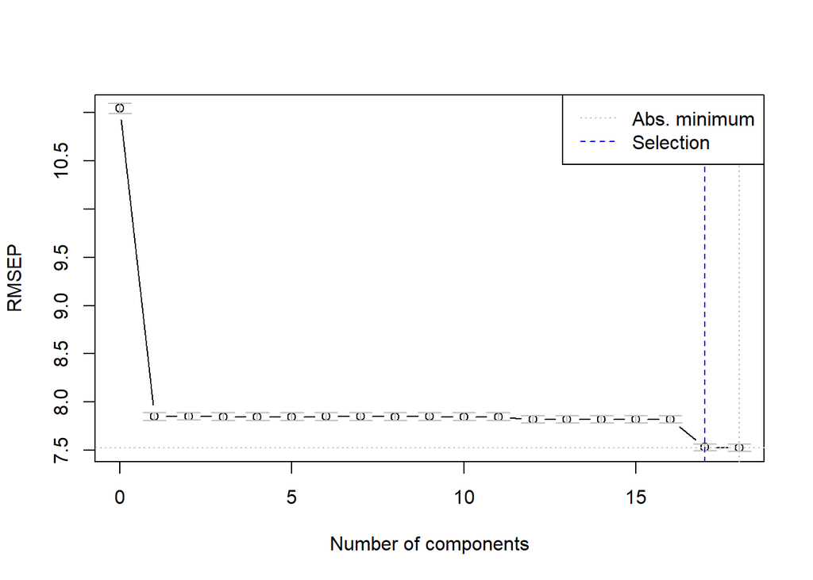

```r
pcr_fit <- pcr(Food_Insecurity_Rate_. ~ .,
               data = pcr_train_df,
               scale = FALSE, validation = "CV")

pcr_cv <- drop(RMSEP(pcr_fit, estimate = "CV")$val[1, 1, -1])
pcr_ncomp <- pls::selectNcomp(pcr_fit, method = "onesigma", plot = TRUE)
```

```r
cat("Best number of components (PCR):", pcr_ncomp, "\n")
```

```
## Best number of components (PCR): 17
```

```r
register_model(
  name = "pcr",
  pred = drop(predict(pcr_fit, newdata = pcr_test_df, ncomp = pcr_ncomp)),
  p = pcr_ncomp + 1
)
postResample(pred = test_results$pcr, obs = test_results$actual)
```

```
##      RMSE  Rsquared       MAE
## 7.5485781 0.5400902 5.9935926
```

According to PCR, the best number of components is 17 - which is almost the entire amount of numeric variables (18), while the model’s metrics remain consistent with the original OLS model.

The graph shows that there is a significant drop in RMSEP after the first component, indicating that the first component (according to the original model, poverty) has the strongest explanatory power and accounts for most of the model’s variance.

Now PLS will be attempted.

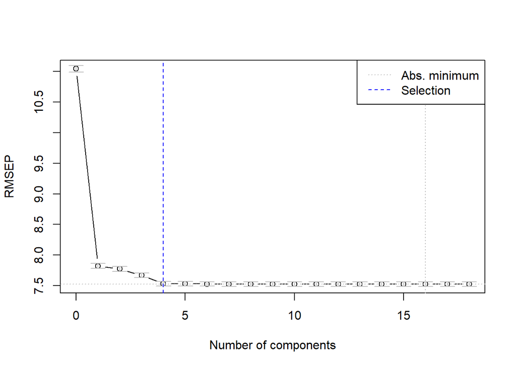

```r
pls_fit <- plsr(Food_Insecurity_Rate_. ~ .,
                data = pcr_train_df,
                scale = FALSE, validation = "CV")

pls_cv <- drop(RMSEP(pls_fit, estimate = "CV")$val[1, 1, -1])
pls_ncomp <- pls::selectNcomp(pls_fit, method = "onesigma", plot = TRUE)
```

```r
cat("Best number of components (PLS):", pls_ncomp, "\n")
```

```
## Best number of components (PLS): 4
```

```r
register_model(
  name = "pls",
  pred = drop(predict(pls_fit, newdata = pcr_test_df, ncomp = pls_ncomp)),
  p = pls_ncomp + 1
)
postResample(pred = test_results$pls, obs = test_results$actual)
```

```
##      RMSE  Rsquared       MAE
## 7.5516071 0.5397223 5.9962378
```

From the graph we can see that, differently from the PCR graph, the first 4 components have more explanatory power, and are the best number of components according to this method.

The model’s metrics are similar to the original OLS model, but the R squared is slightly smaller.

### - models’ comparison

```r
#Mean Absolute Error for all models
mae_results <- apply(test_results[-1], 2, function(x) mean(abs(x - test_results$actual)))

sort(mae_results)
```

```
##        ridge        lasso OLS_baseline   forward_CV  forward_AIC     both_AIC
##     5.989244     5.989246     5.989246     5.989309     5.989679     5.989679
##          pcr          pls
##     5.993593     5.996238
```

[figure not shown]

```r
mae_df <- data.frame(Model = names(mae_results), MAE = mae_results)
ggplot(mae_df, aes(x = reorder(Model, MAE), y = MAE)) +
  geom_bar(stat = "identity", fill = "steelblue") +
  coord_flip() +
  labs(title = "Model Comparison (Test MAE, log price)", x = "Model", y = "MAE") +
  theme_minimal()
```

The MAE is consistent across models; poverty is the main predictor across different models, with other few relevant variables - but still with smaller impacts - almost dominates the increase or decrease of food insecurity rates in countries affected by war.

### - neural network

To broaden the scope of the project and to try different methods that could improve prediction, a simple neural network for regression will be developed.

```r
set.seed(240603)

ctrl_reg <- trainControl(
  method = "repeatedcv",
  number = 5,
  repeats = 1
)

nn_fit <- train(
  ModelF,       #ModelF, already with feature engineering done and standardized
  data = training,
  method = "nnet",
  metric = "RMSE",
  preProcess = c("center", "scale"),
  trControl = trainControl(method = "repeatedcv", number = 5, repeats = 1),
  tuneGrid = expand.grid(
    size  = c(3, 5),
    decay = c(0, 0.01, 0.1)
  ),
  trace  = FALSE,
  linout = TRUE,
  maxit  = 300,
  MaxNWts = 2000
)

nn_fit
```

```
## Neural Network
##
## 40860 samples
##    18 predictor
##
## Pre-processing: centered (18), scaled (18)
## Resampling: Cross-Validated (5 fold, repeated 1 times)
## Summary of sample sizes: 32689, 32688, 32688, 32687, 32688
## Resampling results across tuning parameters:
##
##   size  decay  RMSE      Rsquared   MAE
##   3     0.00   6.506360  0.6529211  5.317841
##   3     0.01   6.508827  0.6526544  5.318872
##   3     0.10   6.517463  0.6517125  5.321871
##   5     0.00   6.515896  0.6518885  5.323760
##   5     0.01   6.544043  0.6489542  5.329331
##   5     0.10   6.514593  0.6520546  5.321835
##
## RMSE was used to select the optimal model using the smallest value.
## The final values used for the model were size = 3 and decay = 0.
```

```r
#evaluation on test set
nn_pred <- predict(nn_fit, newdata = testing)

as_tibble_row(postResample(pred = nn_pred,
                           obs = testing$Food_Insecurity_Rate_.)) |>
  mutate(Model = "Neural Network", .before = 1)
```

```
## # A tibble: 1 × 4
##   Model           RMSE Rsquared   MAE
##   <chr>          <dbl>    <dbl> <dbl>
## 1 Neural Network  6.46    0.664  5.27
```

```r
#register the model
register_model(
  name = "neural_net",
  pred = predict(nn_fit, newdata = testing),
  p    = nn_fit$bestTune$size
)
postResample(pred = test_results$neural_net, obs = test_results$actual)
```

```
##     RMSE Rsquared      MAE
## 6.456534 0.663538 5.266211
```

Plotting the results on predicted vs observed.

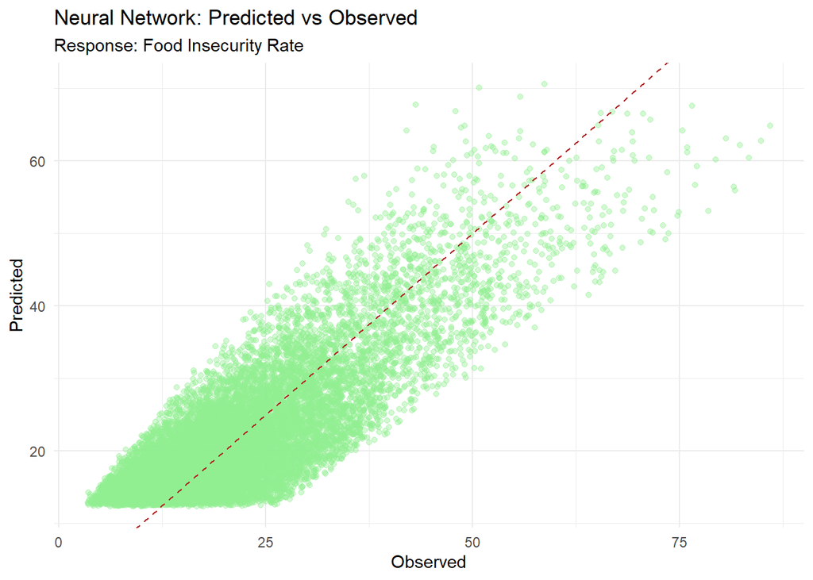

```r
tibble(
  observed  = testing$Food_Insecurity_Rate_.,
  predicted = nn_pred) |>
  ggplot(aes(x = observed, y = predicted)) +
  geom_point(alpha = 0.4, color = "lightgreen") +
  geom_abline(slope = 1, intercept = 0, linetype = "dashed",
              color = "firebrick") +
  labs(
    title    = "Neural Network: Predicted vs Observed",
    subtitle = "Response: Food Insecurity Rate",
    x = "Observed", y = "Predicted"
  ) +
  theme_minimal()
```

The neural network here developed, compared to the other models, has a higher R2, of approximately 66%, which is a significant improvement compared to the constant 54% of all the previous models. The MAE and RMSE are also lower, indicating a lower error. The neural network suggest a good improvement in capturing the non-linear relationships between the predictors and food insecurity rate.

The graph also shows that the model seems to correctly capture the general trend, while struggling to correctly predict the extreme values present in the upper part of the visualization.

In conclusion, the OLS, regularization and dimensionality reduction models did not differ among each other, having a stable 54% of variance explainated. The driving predictors for food insecurity are poverty-related variables. The neural network was the only method that showed significant improvement, explaining around 66% of variance. This suggests that, to account for the complexity of the variables and their relationship, especially when predicting what influences food insecurity, non-linear models are needed.